# NBA Points Gained Shooting Three Pointers

Chris at Savvy Analtyics

At the Covid induced pause in the 2019-2020 NBA season, my favorite NBA team, the Indiana Pacers, seemed to loose a lot of their games to other teams who were better at the Three Point Shot.

Exactly how bad are the Pacers compared to other teams?

While there are any number of published NBA stats we could turn to, I wanted to get creative and analyze this by incorporating some methods and metrics that are used on the PGA Tour plus some from the world of Finance.

From the PGA Tour we will borrow the “Strokes Gained” metric (read about it here https://www.pgatour.com/news/2016/05/31/strokes-gained-defined.html) and apply it to Three Point shooting. Essentially we will use the season-to-date NBA average points scored via three point shot per game as the baseline and evaluate each team against that running average.

From the world of finance we will use a rate-volume analysis to see how many of those gained points are from volume (attempts) versus rate (percentage made).

This article, like most on R-Pubs, is both instructional and investigative so we will be talking about how to write the code, get the data and display the charts as well as discussing the results. To expose the R code just click on the “Code” button in the right margin to unhide it.

```r
# Load libraries, functions and clear environment

rm(list=ls())
options(scipen=999)
suppressPackageStartupMessages({
require(tidyverse)
require(rvest)
require(lubridate)
require(scales)
})

# Create a function to return zero for null and blank values
zna <- function(x) {
  x <- ifelse(is.null(x), 0,
        ifelse(is.na(x), 0,
          ifelse(x == "", 0, x)))
  return(x)
}
```

Now for some good news / bad news about getting the data we need.

Good News : There is a site with all of the data we need at basketball-reference.com.

Bad News : Getting the data out of the site will require some web scrapping.

Good News : The rvest library is up to the task.

You will see several examples of searching for specific occurrences of html_nodes, html_attr, html_text and html_table in the code blocks below.

All of those have to be scouted out manually by looking at an example page on your browser and right clicking “View Source” or better yet right clicking “Inspect” on the specific element you are looking for. Let’s look at one example which you can leverage to successfully mine this and other websites for data in the future.

For this example we are looking at the Milwaukee Bucks 2020 schedule at: https://www.basketball-reference.com/teams/MIL/2020_games.html

*Figure 1*

[figure not shown]

In Figure 1 you can see the results of right clicking “Inspect” on the row containing the Bucks-Rockets game on 10/24/2019. Therefore we know in the code block below we can find the Opponent Name string via this code:

html_nodes(’*[data-stat=“opp_name”]’) %>% html_text()

Which yields “Houston Rockets”.

Then we can find the date of the game in that same node in the “csk” attribute with:

html_nodes(’*[data-stat=“opp_name”]’) %>% html_attr(“csk”)

Which yields “HOU2019-10-24”

After some quick exploration of the website you can see that the hierarchy of the web pages is:

1. Each season has the teams and rankings with links to each team’s pages
2. Each team page has the schedule with links to each game’s page
3. Each game’s page contains the detailed performance stats we want

So we will follow that hierarchy in gathering our data.

**STEP 1 :** Use the season teams and rankings page to access each team’s schedule and build a complete data frame of the schedule of every team in the league.

```r
# Load the 2020 standings page from Basketball Reference and scrape the
# team URL's from the league standings page


# As of the end of the 2019-2020 season there were 1942 game records which, even at about 1 game per second takes awhile.  Therefore I ran this code and saved the data frame as a RDS file.

FullRefresh <- FALSE # Data pre-loaded to save run time.  You can choose to set FullRefresh to TRUE and run the block yourself

if (FullRefresh) {


# Get the team 2020 URL from the href tags on ".left a" nodes on the page
nba_team_urls <- "https://www.basketball-reference.com/leagues/NBA_2020.html" %>%
  read_html() %>%
  html_nodes(".left a") %>%
  html_attr("href")

# Get the team name from the text in the ".left a" nodes on the page
nba_team_names <- "https://www.basketball-reference.com/leagues/NBA_2020.html" %>%
  read_html() %>%
  html_nodes(".left a") %>%
  html_text()

# The URL captured was the stats page so we need to modify it to be the game schedule page
nba_team_urls <- paste0("https://www.basketball-reference.com", nba_team_urls) %>%
  str_replace("2020", "2020_games")

# Create an empty data frame to hold the schedule for each team
nba_team_results <- data.frame(
  team = as.character(),
  schedule_url = as.character(),
  date = as.character(),
  opponent = as.character(),
  location = as.character(),
  results_url = as.character(),
  stringsAsFactors = FALSE
)

# Loop through the teams load their schedule into the data frame
for (i in 1:length(nba_team_urls)) {
  # Get the url of the game results href link and add the site to make it a full url
  results_url_vector <- nba_team_urls[i] %>%
    read_html() %>%
    html_nodes(".center a") %>%
    html_attr("href")
  results_url_vector <- paste0("https://www.basketball-reference.com",
                               results_url_vector)
  # Get the date from the appropriate node
  results_date_vector <- nba_team_urls[i] %>%
    read_html() %>%
    html_nodes('*[data-stat="opp_name"]') %>%
    html_attr("csk") %>%
    str_extract("\\d\\d\\d\\d\\-\\d\\d\\-\\d\\d")
  results_date_vector <- results_date_vector[!is.na(results_date_vector)]
  # Get the opponent date from the appropriate node
  results_opponent_vector <- nba_team_urls[i] %>%
    read_html() %>%
    html_nodes('*[data-stat="opp_name"]') %>%
    html_text()
  # Get the game location from the appropriate node and interpret the @ as an away game
  results_location_vector <- nba_team_urls[i] %>%
    read_html() %>%
    html_nodes('*[data-stat="game_location"]') %>%
    html_text()
  results_location_vector <- results_location_vector[results_opponent_vector != "Opponent"]
  results_location_vector <- ifelse(results_location_vector == "@", "Away", "Home")
  results_opponent_vector <- results_opponent_vector[results_opponent_vector != "Opponent"]
  # Take the vectors and assemble into to the empty temp data frame of current results
  temp_df <- data.frame(
    team = rep(nba_team_names[i], length(results_url_vector)),
    schedule_url = rep(nba_team_urls[i], length(results_url_vector)),
    date = results_date_vector,
    opponent = results_opponent_vector,
    location = results_location_vector,
    results_url = results_url_vector,
    stringsAsFactors = FALSE
  )
  # Append the temp data frame building the league schedule and results data frame
  nba_team_results <- bind_rows(nba_team_results, temp_df)
}

# Re-class the game date as a proper date type
nba_team_results <- nba_team_results %>%
  mutate(date = as.Date(date, format = "%Y-%m-%d")) %>%
  distinct()

}
```

**STEP 2 :** Use the full league schedule we have built, complete with links to the game results pages, to drill down into those results pages and add game stats to each row of our data frame.

```r
# Again the data was pre-loaded to save time but you can choose to set FullRefresh to TRUE in the block above and run yourself

if (FullRefresh) {

starttime <- Sys.time()

# Create empty data frame to hold results
nba_team_results <- nba_team_results %>%
 mutate(MP = "",
        FG = "",
        FGA = "",
        FGP = "",
        TP = "",
        TPA = "",
        TPP = "",
        FT = "",
        FTA = "",
        FTP = "",
        ORB = "",
        DRB = "",
        TRB = "",
        AST = "",
        STL = "",
        BLK = "",
        TOV = "",
        PF = "",
        PTS = "",
        MARGIN = "")

# Loop through the schedule for each team and pull up the results page
lastprinted <- 0
for (i in 1:nrow(nba_team_results)) {
  # Use the table function to create a list of data frames for
  # each html table on the page
  temp_gamestats <- nba_team_results$results_url[i] %>%
    read_html() %>%
    html_table(fill = TRUE)
  if (nba_team_results$location[i] == "Away") {
    # For away games get the first table in the list
    temp_gamestats <- temp_gamestats[[1]]
    print(paste0("i = ", i, " ",
                 nba_team_results$team[i], " ", nba_team_results$team[i],
                 nba_team_results$location[i], " = Away vs ",
                 nba_team_results$opponent[i]))
  } else {
    # For home games get the 15th table in the list
    temp_gamestats <- temp_gamestats[[15]]
    print(paste0("i = ", i, " ",
                 nba_team_results$team[i], " ", nba_team_results$team[i],
                 nba_team_results$location[i], " = Not Away vs",
                 nba_team_results$opponent[i]))  }
  # Use the first row as column names
  colnames(temp_gamestats) <- temp_gamestats[1,]
  # Filter to just the team totals; ignore player stats
  temp_gamestats <- temp_gamestats %>%
     filter(Starters == "Team Totals") %>%
     rename("FGP" = "FG%",
            TP = "3P",
            TPA = "3PA",
            TPP = "3P%",
            FTP = "FT%",
            MARGIN = "+/-")
  # Apply the ZNA function to the stat fields to replace NA or blank values with zero
  nba_team_results$MP[i] = zna(temp_gamestats$MP)
  nba_team_results$FG[i] = zna(temp_gamestats$FG)
  nba_team_results$FGA[i] = zna(temp_gamestats$FGA)
  nba_team_results$FGP[i] = zna(temp_gamestats$FGP)
  nba_team_results$TP[i] = zna(temp_gamestats$TP)
  nba_team_results$TPA[i] = zna(temp_gamestats$TPA)
  nba_team_results$TPP[i] = zna(temp_gamestats$TPP)
  nba_team_results$FT[i] = zna(temp_gamestats$FT)
  nba_team_results$FTA[i] = zna(temp_gamestats$FTA)
  nba_team_results$FTP[i] = zna(temp_gamestats$FTP)
  nba_team_results$ORB[i] = zna(temp_gamestats$ORG)
  nba_team_results$DRB[i] = zna(temp_gamestats$DRB)
  nba_team_results$TRB[i] = zna(temp_gamestats$TRB)
  nba_team_results$AST[i] = zna(temp_gamestats$AST)
  nba_team_results$STL[i] = zna(temp_gamestats$STL)
  nba_team_results$BLK[i] = zna(temp_gamestats$BLK)
  nba_team_results$TOV[i] = zna(temp_gamestats$TOV)
  nba_team_results$PF[i] = zna(temp_gamestats$PF)
  nba_team_results$PTS[i] = zna(temp_gamestats$PTS)
  nba_team_results$MARGIN[i] = zna(temp_gamestats$MARGIN)
  # Print results every 50 pages to show progress as this runs for a long time
  if (i > lastprinted + 50) {
    print(paste0("Execution Time : ", difftime(Sys.time(), starttime)))
    print(paste0("Record Number : ", i))
    lastprinted <- lastprinted + 50
  }

}

# Re-class the character fields as numeric
nba_team_results <- nba_team_results %>%
  mutate(
    MP = as.numeric(MP),
    FG = as.numeric(FG),
    FGA = as.numeric(FGA),
    FGP = as.numeric(FGP),
    TP = as.numeric(TP),
    TPA = as.numeric(TPA),
    TPP = as.numeric(TPP),
    FT = as.numeric(FT),
    FTA = as.numeric(FTA),
    FTP = as.numeric(FTP),
    ORB = as.numeric(ORB),
    DRB = as.numeric(DRB),
    TRB = as.numeric(TRB),
    AST = as.numeric(AST),
    STL = as.numeric(STL),
    BLK = as.numeric(BLK),
    TOV = as.numeric(TOV),
    PF = as.numeric(PF),
    PTS = as.numeric(PTS),
    MARGIN = as.numeric(MARGIN))

# Re-calc offensive rebounds
 nba_team_results <- nba_team_results %>%
    mutate(ORB = TRB - DRB)

}
```

**STEP 3 :** Simple aggregation. Now that we have our complete results and statistics we will calculate running totals as well as overall league averages so that comparisons can be made between each team and the league overall at any given point during the season.

```r
# Use the cumsum function to calculate the running totals for appropriate fields
agg_team_day <- nba_team_results %>%
  distinct() %>%
  group_by(team) %>%
  mutate(
          RUNFG = cumsum(FG),
          RUNFGA = cumsum(FGA),
          RUNFGP = RUNFG / RUNFGA,
          RUNTP = cumsum(TP),
          RUNTPA = cumsum(TPA),
          RUNTPP = RUNTP / RUNTPA,
          RUNFT = cumsum(FT),
          RUNFTA = cumsum(FTA),
          RUNFTP = RUNFT / RUNFTA,
          RUNORB = cumsum(ORB),
          RUNDRB = cumsum(DRB),
          RUNTRB = cumsum(TRB),
          RUNAST = cumsum(AST),
          RUNSTL = cumsum(STL),
          RUNBLK = cumsum(BLK),
          RUNTOV = cumsum(TOV),
          RUNPF = cumsum(PF),
          RUNPTS = cumsum(PTS)) %>%
  ungroup() %>%
  group_by(team) %>%
  mutate(RunGames = row_number()) %>%
  ungroup()

# Create a league aggregate so that we can compare each team to the overall league on any given day; complete with running totals
agg_league_day <- agg_team_day %>%
  group_by(date) %>%
  summarise(NBAFG = sum(FG),
          NBAFGA = sum(FGA),
          NBAFGP = mean(FGA),
          NBATP = sum(TP),
          NBATPA = sum(TPA),
          NBATPP = mean(TPP),
          NBAFT = sum(FT),
          NBAFTA = sum(FTA),
          NBAFTP = mean(FTP),
          NBAORB = sum(ORB),
          NBADRB = sum(DRB),
          NBATRB = sum(TRB),
          NBAAST = sum(AST),
          NBASTL = sum(STL),
          NBABLK = sum(BLK),
          NBATOV = sum(TOV),
          NBAPF = sum(PF),
          NBAPTS = sum(PTS),
          NBAGames = n()) %>%
  arrange(date) %>%
  mutate(
        NBARUNFG = cumsum(NBAFG),
        NBARUNFGA = cumsum(NBAFGA),
        NBARUNFGP = NBARUNFG / NBARUNFGA,
        NBARUNTP = cumsum(NBATP),
        NBARUNTPA = cumsum(NBATPA),
        NBARUNTPP = NBARUNTP / NBARUNTPA,
        NBARUNFT = cumsum(NBAFT),
        NBARUNFTA = cumsum(NBAFTA),
        NBARUNFTP = NBARUNFT / NBARUNFTA,
        NBARUNORB = cumsum(NBAORB),
        NBARUNDRB = cumsum(NBADRB),
        NBARUNTRB = cumsum(NBATRB),
        NBARUNAST = cumsum(NBAAST),
        NBARUNSTL = cumsum(NBASTL),
        NBARUNBLK = cumsum(NBABLK),
        NBARUNTOV = cumsum(NBATOV),
        NBARUNPF = cumsum(NBAPF),
        NBARUNPTS = cumsum(NBAPTS),
        NBARunGames = cumsum(NBAGames))
```

**STEP 4 :** Targeted aggregation where we build our “points gained” metrics

Now that we have day by day totals and running totals for each team and the league at large we can calculate the points gained for each scoring cohort; Free Throws (FT), Two Pointers (DP) and Three Pointers (TP).

Here is a non-code breakdown of how a few of the metrics are calculated.

Points Gained Three Point Shooting : Each team’s total points scored via three point shooting (made three point baskets X 3) is compared to the league average. If the league averages 36 per game and a team averages 40 per game then that team’s points gained is 4. Conversely if a team averages 30 then that team’s points gained is -6.

(RUNTP / RunGames - NBARUNTP / NBARunGames) X 3

Points Gained Three Point Shooting - Volume Driven : A team can score more points with the three point shot by either taking more shots (Volume) or making a higher percentage of the shots they take (Rate). To isolate the volume we hold the rate constant. The team’s attempts per game is compared to the league’s and then multiplied by the league average. This tells us how many points per game that team would gain versus the league if they made the same percentage of shots that the league does.

((RUNTPA / RunGames - NBARUNTPA / NBARunGames) X NBARUNTPP) X 3

Points Gained Three Point Shooting - Rate Driven : To isolate the rate we hold the volume constant. The team’s make percentage per game is compared to the league’s and then multiplied by the league average attempts. This tells us how many points per game that team would gain versus the league if they attempted the same number of shots that the league does.

((RUNTPP - NBARUNTPP) X NBARUNTPA / NBARunGames) X 3

```r
agg_team_points_gained <- agg_team_day %>%
  dplyr::select(team, date, opponent, RUNFG, RUNFGA, RUNFGP,
                RUNTP, RUNTPA, RUNTPP, RUNFT, RUNFTA, RUNFTP, RunGames) %>%
  inner_join(agg_league_day %>%
               dplyr::select(date, NBARUNFG, NBARUNFGA, NBARUNFGP,
                NBARUNTP, NBARUNTPA, NBARUNTPP, NBARUNFT, NBARUNFTA,
                NBARUNFTP, NBARunGames), by = c("date")) %>%
  mutate(RunPointsGainedDGTot = ((RUNFG - RUNTP) / RunGames
                                 - (NBARUNFG - NBARUNTP) / NBARunGames) * 2,
         RunPointsGainedDGVol = (((RUNFGA - RUNTPA) / RunGames
                                  - (NBARUNFGA - NBARUNTPA) /
                                 NBARunGames) * NBARUNFGP) * 2,
         RunPointsGainedDGRate = ((((RUNFGA - RUNTPA) / (RUNFG - RUNTP))
                                   - ((NBARUNFGA - NBARUNTPA) /
                                        (NBARUNFG - NBARUNTP)))
                                  * (NBARUNFGA - NBARUNTPA) / NBARunGames) * 2,


         RunPointsGainedTPTot = (RUNTP / RunGames - NBARUNTP / NBARunGames) * 3,
         RunPointsGainedTPVol = ((RUNTPA / RunGames - NBARUNTPA /
                                 NBARunGames) * NBARUNTPP) * 3,
         RunPointsGainedTPRate = ((RUNTPP - NBARUNTPP) * NBARUNTPA / NBARunGames) * 3,
         RunPointsGainedFTTot = RUNFT / RunGames - NBARUNFT / NBARunGames,
         RunPointsGainedFTVol = (RUNFTA / RunGames - NBARUNFTA /
                                NBARunGames) * NBARUNFTP,
         RunPointsGainedFTRate = (RUNFTP - NBARUNFTP) * NBARUNFTA / NBARunGames)
```

**FINAL STEP : Visualize**

Now we are ready to visualize some results. Let’s start by looking at the points generated by the three point shot has trended or the season across the league.

The chart starts on 11/15 to so that the league has a chance to build enough data to eliminate wild swings in this per-game metric.

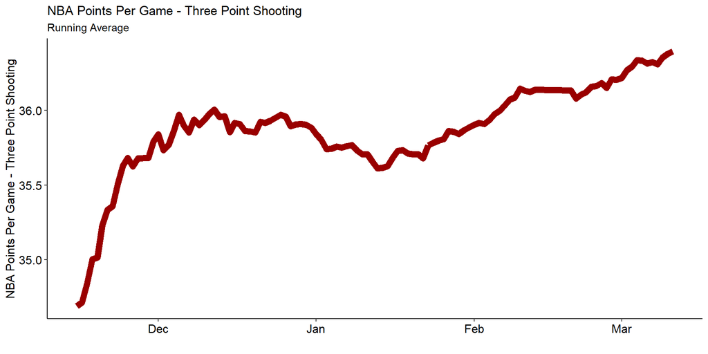

```r
agg_team_points_gained %>%
  filter(date >= as.Date('2019-11-15')) %>%
  mutate(TPPG = NBARUNTP * 3 / NBARunGames) %>%
  ggplot(aes(date, TPPG)) +
  geom_line(color = "#990000", size = 3) +
  theme_classic() +
  theme(axis.text = element_text(size = 12, color = "black"),
        axis.title = element_text(size = 12, color = "black"))  +
  labs(title = "NBA Points Per Game - Three Point Shooting",
       subtitle = "Running Average",
       x = "",
       y = "NBA Points Per Game - Three Point Shooting")
```

Teams got slightly better at 3 point scoring as the season progressed! On average they were scoring 2 more points per game when the season paused than they were on November 15th.

Now that we have established the league average we can investigate our “Points Gained” metric.

Showing all 30 teams in the NBA would be a busy chart so we will compare our Pacers to the other Eastern Conference playoff contenders.

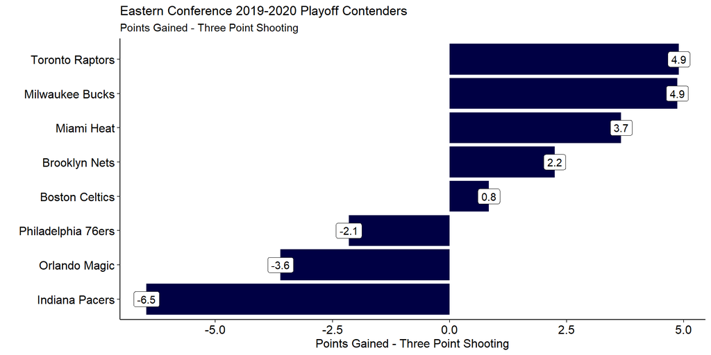

```r
agg_team_points_gained %>%
  filter(team %in% nba_team_names[1:8]) %>%
  group_by(team) %>%
  mutate(maxdate = max(date)) %>%
  filter(date == maxdate) %>%
  ggplot(aes(reorder(team, RunPointsGainedTPTot), RunPointsGainedTPTot)) +
  geom_col(fill = "#000044") +
  geom_label(aes(label=round(RunPointsGainedTPTot,1))) +
  theme_classic() +
  theme(axis.text = element_text(size = 12, color = "black"),
        axis.title = element_text(size = 12, color = "black"))  +
  coord_flip() +
  labs(title = "Eastern Conference 2019-2020 Playoff Contenders",
       subtitle = "Points Gained - Three Point Shooting",
       x = "",
       y = "Points Gained - Three Point Shooting")
```

If you are a Pacer fan, this chart is no surprise. The Pacers are dead last on the list of the top 8 teams in the conference. How has this trended over the season?

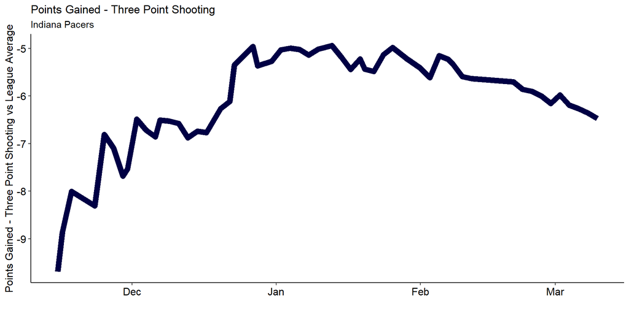

```r
agg_team_points_gained %>%
  filter(team == "Indiana Pacers" &
         date >= as.Date('2019-11-15')) %>%
  ggplot(aes(date, RunPointsGainedTPTot)) +
  geom_line(color = "#000044", size = 3) +
  theme_classic() +
  theme(axis.text = element_text(size = 12, color = "black"),
        axis.title = element_text(size = 12, color = "black"))  +
  labs(title = "Points Gained - Three Point Shooting",
       subtitle = "Indiana Pacers",
       x = "",
       y = "Points Gained - Three Point Shooting vs League Average")
```

This drop coincides with Victor Oladipo’s return but we won’t be exploring any causality in this analysis.

Finally let’s look at how much of the Pacer’s three point shooting performance is rate driven versus volume driven.

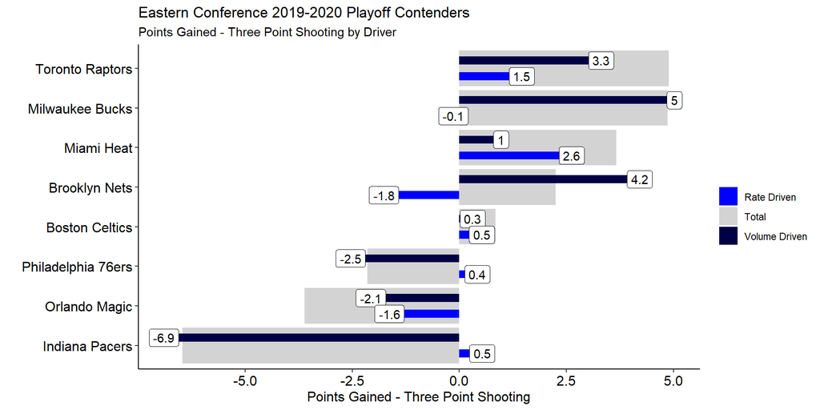

```r
# Create a key of names and fill colors so that we can create a manual legend
Key <- c("Total" = "light grey", "Volume Driven" = "#000044", "Rate Driven" = "blue")

# Isolate the Three Point Volume and plot it
agg_team_points_gained %>%
  filter(team %in% nba_team_names[1:8]) %>%
  group_by(team) %>%
  mutate(maxdate = max(date)) %>%
  filter(date == maxdate) %>%
  # Base plot is total points
  ggplot(aes(reorder(team, RunPointsGainedTPTot), RunPointsGainedTPTot)) +
  geom_col(aes(reorder(team, RunPointsGainedTPTot), RunPointsGainedTPTot,
           fill = "Total")) +
  # Add Volume plot
  geom_col(aes(reorder(team, RunPointsGainedTPTot), RunPointsGainedTPVol,
           fill = "Volume Driven"), width = .2, position = position_nudge(x = 0.2)) +
  geom_label(aes(reorder(team, RunPointsGainedTPTot), RunPointsGainedTPVol,
                 label=round(RunPointsGainedTPVol,1)),
             position = position_nudge(x = 0.2)) +
  # Add Rate Plot
  geom_col(aes(reorder(team, RunPointsGainedTPTot), RunPointsGainedTPRate,
           fill = "Rate Driven"), width = .2, position = position_nudge(x = -0.2)) +
  geom_label(aes(reorder(team, RunPointsGainedTPTot), RunPointsGainedTPRate,
                 label=round(RunPointsGainedTPRate,1)),
             position = position_nudge(x = -0.2)) +
  scale_fill_manual(name = "", values = Key) +
  theme_classic() +
  theme(axis.text = element_text(size = 12, color = "black"),
        axis.title = element_text(size = 12, color = "black"))  +
  coord_flip() +
  labs(title = "Eastern Conference 2019-2020 Playoff Contenders",
       subtitle = "Points Gained - Three Point Shooting by Driver",
       x = "",
       y = "Points Gained - Three Point Shooting")
```

The Pacers loose about 6.5 points per game to the league and we can see that ALL of that is due to volume (0.45 gained by rate - 6.92 lost by volume = 6.47).

It’s interesting to compare the rate and volume of the top teams in the conference and see some of the outliers.

- The Pacers deficit in shot attempts
- The Nets deficit in shot percentage
- The Raptors are good at both
- The Bucks just take more shots

I hope you have enjoyed this look at “Points Gained”.

Be Savvy.